# Jasmine_ONeal_Unit2_HW

Jasmine O’Neal

2023-01-11

## Exercise 1: Conceptual Questions

1. Briefly explain the bias variance trade off as a concept.
   - The goal is to achieve a low MSE, so need to find a good balance between bias and variance. A model that suffers from high bias and low variance usually means the model is too simple with a small number of predictor variables hence prediction instability. A model that suffers from high variance and low bias has too many predictors and hard to replicate fit on different data-sets especially on test sets. Therefore, trade-off in building a model with the right level of complexity depends on the balance of these elements.
2. If a knn model performs poorly using a value of $k=1$, then is it suffering due to bias or variance?
   - Variance. The model has a higher chance of error on the validation set as the predictions made on the training set was limited to begin with.
3. What is the main purpose of feature selection?
   - The main purpose of feature selection is to find out what predictor variables should be used in a given model. This is usually done via software.
4. When using glmnet, what does the penalty term effectively do to your regression model? For example, what does it do if the penalty term is very large?
   - It determines the number of predictors that will be used for that model. If the penalty term is high then the number of predictors will be smaller.

## Exercise 2: Using GLMNET

In the homework assignment for unit 1, we examined the residuals of various polynomial fits to a data set to determine roughly how complex of a polynomial fit is needed. With our new found knowledge of GLMNET and cross validation, we can investigate this a bit more realistically. The data set is generated below.

Use the `caret` package and codes from prelive to perform a LASSO model ($\alpha=1$) with GLMNET with potentially up to 10 polynomial terms and determine what highest order degree is needed. Use 5-fold cross validation. Provide the necessary output and brief explanation to justify your answer.

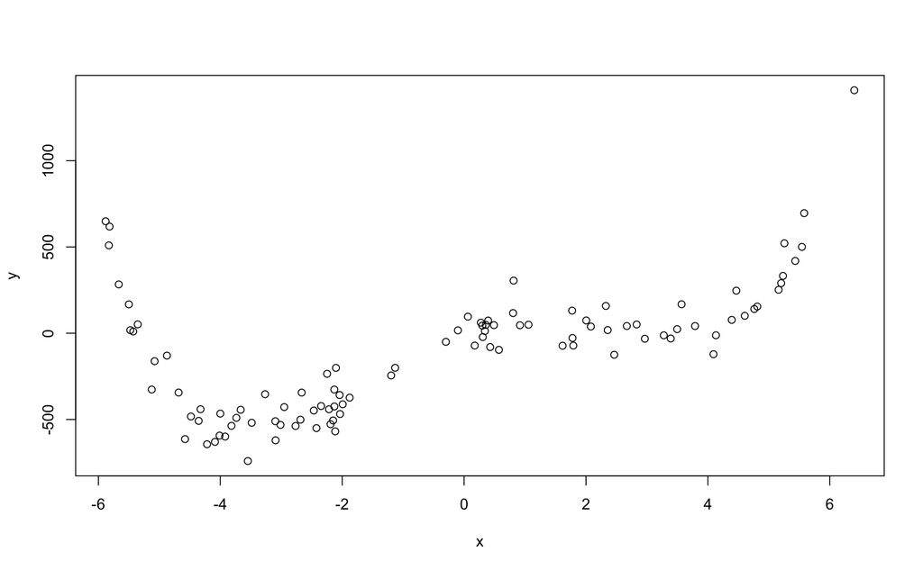

```r
set.seed(1234)
x<-runif(100,-6,6.5)
trend<- 2*x^4-2*x^3-50*x^2+100*x+2
y<-trend+rnorm(100,0,100)
plot(x,y)
```

```r
#10 polynomials
set.seed(1234)
x<-runif(100,-6,6.5)
trend<- 2*x^4-2*x^3-50*x^2+100*x+2
y<-trend+rnorm(100,0,100)
mymodel<-lm(y~poly(x,10))

#par(mfrow=c(1,3))
#plot(x,y)

summary(mymodel)
```

```
##
## Call:
## lm(formula = y ~ poly(x, 10))
##
## Residuals:
##      Min       1Q   Median       3Q      Max
## -197.513  -52.926   -2.497   41.619  251.182
##
## Coefficients:
##                Estimate Std. Error t value Pr(>|t|)
## (Intercept)    -109.255      9.353 -11.681   <2e-16 ***
## poly(x, 10)1   2062.817     93.533  22.054   <2e-16 ***
## poly(x, 10)2   1633.274     93.533  17.462   <2e-16 ***
## poly(x, 10)3  -1050.345     93.533 -11.230   <2e-16 ***
## poly(x, 10)4   2079.672     93.533  22.235   <2e-16 ***
## poly(x, 10)5    -36.461     93.533  -0.390   0.6976
## poly(x, 10)6    156.436     93.533   1.673   0.0979 .
## poly(x, 10)7   -117.938     93.533  -1.261   0.2106
## poly(x, 10)8    110.743     93.533   1.184   0.2396
## poly(x, 10)9    -22.777     93.533  -0.244   0.8082
## poly(x, 10)10  -111.650     93.533  -1.194   0.2358
## ---
## Signif. codes:  0 '***' 0.001 '**' 0.01 '*' 0.05 '.' 0.1 ' ' 1
##
## Residual standard error: 93.53 on 89 degrees of freedom
## Multiple R-squared:  0.941,  Adjusted R-squared:  0.9344
## F-statistic: 141.9 on 10 and 89 DF,  p-value: < 2.2e-16
```

```r
#create dataframe
x<-runif(100,-6,6.5)
y<-trend+rnorm(100,0,100)
df<-data.frame(x,y)
```

```r
#glmnet with 5-fold cross validation
#10 polynomials
#k fold parameters
library(caret)
fitControl <- trainControl(method = "repeatedcv", number = 5, repeats = 1)

#fitting glmnet
set.seed(1234)
glmnet.fit <- train((y) ~ poly(x, 10),
              data = df,
              method = "glmnet",
              tuneGrid = expand.grid(alpha = 1, lambda = 1:10),
              trControl = fitControl
              )

glmnet.fit
```

```
## glmnet
##
## 100 samples
##   1 predictor
##
## No pre-processing
## Resampling: Cross-Validated (5 fold, repeated 1 times)
## Summary of sample sizes: 80, 80, 80, 80, 80
## Resampling results across tuning parameters:
##
##   lambda  RMSE      Rsquared    MAE
##    1      387.3642  0.02454744  310.5054
##    2      385.3509  0.02431860  308.9449
##    3      383.4696  0.02416464  307.5058
##    4      381.7307  0.02404825  306.1787
##    5      380.0705  0.02398165  304.8214
##    6      378.4802  0.02395804  303.4732
##    7      377.0097  0.02400459  302.1504
##    8      375.5766  0.02410409  300.8589
##    9      374.1676  0.02439336  299.6522
##   10      372.8017  0.02468704  298.4583
##
## Tuning parameter 'alpha' was held constant at a value of 1
## RMSE was used to select the optimal model using the smallest value.
## The final values used for the model were alpha = 1 and lambda = 10.
```

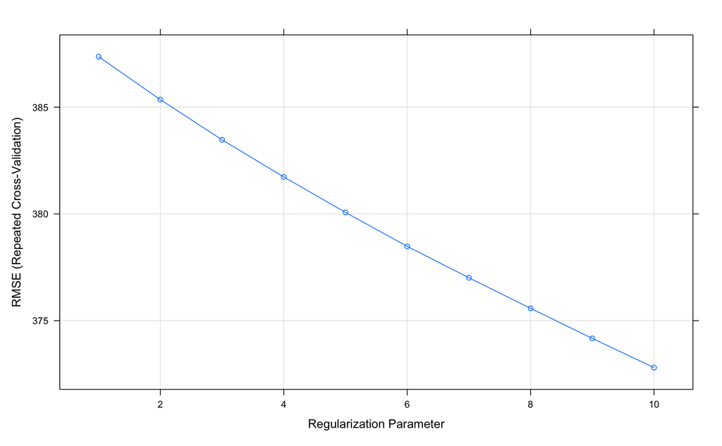

```r
plot(glmnet.fit)
```

```r
opt.pen<-glmnet.fit$finalModel$lambdaOpt #penalty term
coef(glmnet.fit$finalModel,opt.pen)
```

```
## 11 x 1 sparse Matrix of class "dgCMatrix"
##                       s1
## (Intercept)   -101.77014
## poly(x, 10)1     .
## poly(x, 10)2    47.07699
## poly(x, 10)3     .
## poly(x, 10)4  -603.23033
## poly(x, 10)5  -125.06208
## poly(x, 10)6  -469.93565
## poly(x, 10)7  -482.22748
## poly(x, 10)8  -374.74991
## poly(x, 10)9   -91.96756
## poly(x, 10)10    .
```

## Exercise 3: Feature selection is not a fix all

When people start to learn how to build predictive models, they tend to focus on building the model and do not think enough about what the model is trying to do. In the case of linear regression, we are fitting linear trends unless we are adding complexity via transformations, polynomial terms, and interaction terms.

Consider the following data set located in the `ISLR` package which contains the salary (in thousands) of Major League baseball players as well as some of their performance statistics both currently and over their career. The variables that begin with the letter C such as CHits stands for the number of hits in their career versus the variable Hits, which is just the number of hits they have on the current salaries.

```r
library(ISLR) #For the baseball data set
Hitters2 =na.omit(Hitters)
which(rownames(Hitters2)=="-Mike Schmidt")
```

```
## [1] 173
```

```r
Hitters2<-Hitters2[-173,]
```

Suppose a novice data analyst runs the following regression model to perform feature selection. They will use this model to not only predict future Salaries of players that were not included in the study but also provide interpretation as to which statistics are associated to Salary.

```r
library(caret)
set.seed(1234)
fitControl<-trainControl(method="repeatedcv",number=10,repeats=1)
glmnet.fit<-train(Salary~.,
               data=Hitters2,
               method="glmnet",
               trControl=fitControl
               )
opt.pen<-glmnet.fit$finalModel$lambdaOpt
coef(glmnet.fit$finalModel,opt.pen)
glmnet.fit
```

[output not shown]

```r
#glmnet model output
opt.pen<-glmnet.fit$finalModel$lambdaOpt #penalty term
coef(glmnet.fit$finalModel,opt.pen)
```

```
## 20 x 1 sparse Matrix of class "dgCMatrix"
##                        s1
## (Intercept) -6.092777e+01
## AtBat        .
## Hits         1.865437e+00
## HmRun        .
## Runs         5.962663e-01
## RBI          3.499865e-01
## Walks        2.453095e+00
## Years        .
## CAtBat       .
## CHits        8.952858e-02
## CHmRun       4.304995e-01
## CRuns        1.689554e-01
## CRBI         1.915952e-01
## CWalks       .
## LeagueN      1.867512e+01
## DivisionW   -9.371712e+01
## PutOuts      2.325531e-01
## Assists     -3.984272e-04
## Errors      -1.328591e+00
## NewLeagueN   .
```

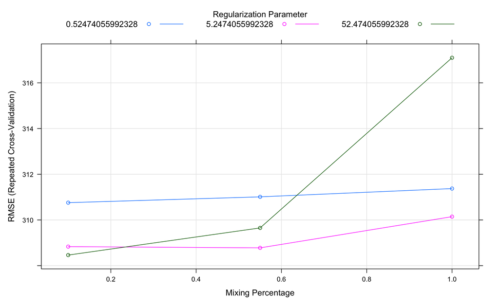

```r
plot(glmnet.fit)
```

## A. Although you can predict with a glmnet model, it doesn’t offer any traditional hypothesis testing or diagnostics of the model fit. Use the traditional `lm` function to fit a regression model including only the predictors that the glmnet function call above suggests. Provide the residual plots of the model and provide commentary on what you see.

```r
#regression model
salarymodel = lm(Salary ~ Hits + Runs + RBI + Walks + CHits + CHmRun + CRuns + CRBI + League + Division + PutOuts + Assists + Errors, data = Hitters2)

#summary
summary(salarymodel)
```

```
##
## Call:
## lm(formula = Salary ~ Hits + Runs + RBI + Walks + CHits + CHmRun +
##     CRuns + CRBI + League + Division + PutOuts + Assists + Errors,
##     data = Hitters2)
##
## Residuals:
##     Min      1Q  Median      3Q     Max
## -904.68 -162.16  -16.75  121.70 1107.19
##
## Coefficients:
##               Estimate Std. Error t value Pr(>|t|)
## (Intercept)  -95.38855   63.05030  -1.513 0.131579
## Hits           3.78556    1.36382   2.776 0.005928 **
## Runs          -1.80325    2.45610  -0.734 0.463524
## RBI           -0.62889    1.55007  -0.406 0.685299
## Walks          2.90696    1.33967   2.170 0.030963 *
## CHits         -0.16198    0.37095  -0.437 0.662728
## CHmRun        -0.28150    1.31109  -0.215 0.830170
## CRuns          0.47007    0.55218   0.851 0.395430
## CRBI           0.57573    0.58028   0.992 0.322089
## LeagueN       29.17307   39.45085   0.739 0.460316
## DivisionW   -112.14585   37.97289  -2.953 0.003446 **
## PutOuts        0.25361    0.07302   3.473 0.000607 ***
## Assists       -0.11107    0.20141  -0.551 0.581824
## Errors        -1.67165    4.14269  -0.404 0.686916
## ---
## Signif. codes:  0 '***' 0.001 '**' 0.01 '*' 0.05 '.' 0.1 ' ' 1
##
## Residual standard error: 301.1 on 248 degrees of freedom
## Multiple R-squared:  0.5572, Adjusted R-squared:  0.534
## F-statistic:    24 on 13 and 248 DF,  p-value: < 2.2e-16
```

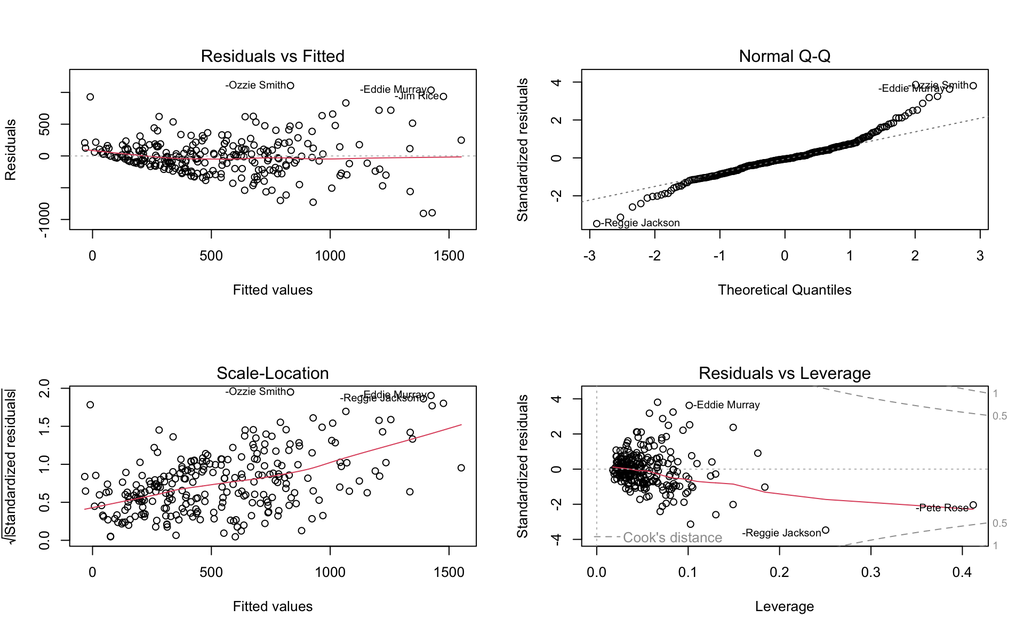

```r
#residual plots
par(mfrow=c(2,2))
plot(salarymodel)
```

## Discuss Residual Plots Output

1. Residual vs Fitted Plot: The data is not randomly scattered indicating a variance issue
2. Normal Q-Q Plot: The data doesn’t mostly fall on the line indicating a normality issue
3. There doesn’t appear to be any data points with high leverage, though Pete Rose data point comes close
4. Independence: Since we don’t know how the data was selected, we will assume independence

## B. Compute the VIFs of the model.

```r
# review VIFs
# load car package
library(car)
# examine VIFs
vif(salarymodel)
```

```
##       Hits       Runs        RBI      Walks      CHits     CHmRun      CRuns
##  10.710177  11.170787   4.580976   2.412680 166.302986  33.476221  96.225251
##       CRBI     League   Division    PutOuts    Assists     Errors
## 101.360973   1.120209   1.041186   1.204817   2.462949   2.163371
```

## C. Consider the following plot. Remake this plot two additional ways: one logging the salary and two logging both salary and career RBIS. Which setting provides the most evidence of getting a good fit with a regression model?

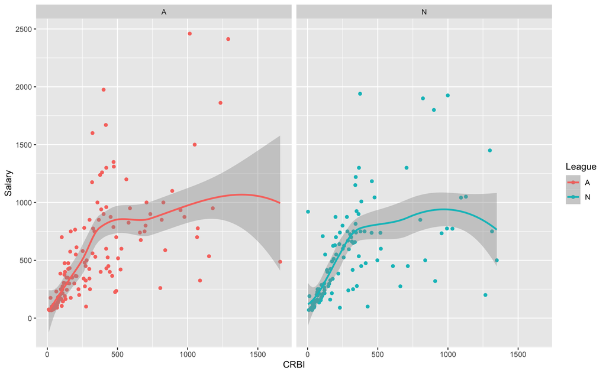

```r
#plot CRBI and Salary
library(ggplot2)
ggplot(Hitters2,aes(x=CRBI,y=Salary,color=League))+geom_point()+geom_smooth(method='loess',formula='y~x')+facet_wrap(~League)
```

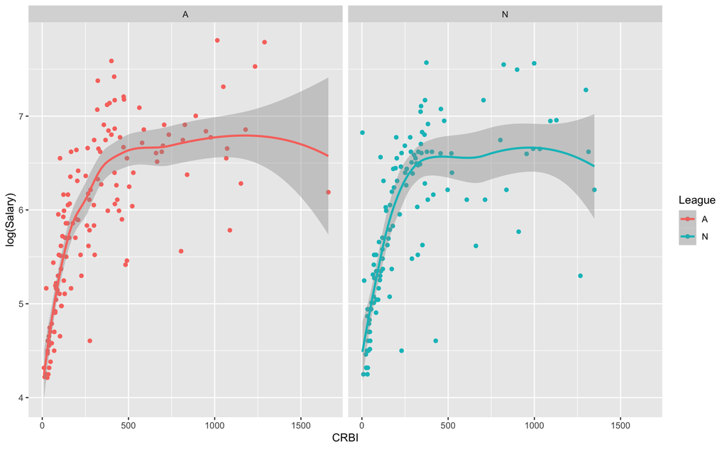

```r
library(ggplot2)
# log Salary
ggplot(Hitters2,aes(x=CRBI,y=log(Salary),color=League))+geom_point()+geom_smooth(method='loess',formula='y~x')+facet_wrap(~League)
```

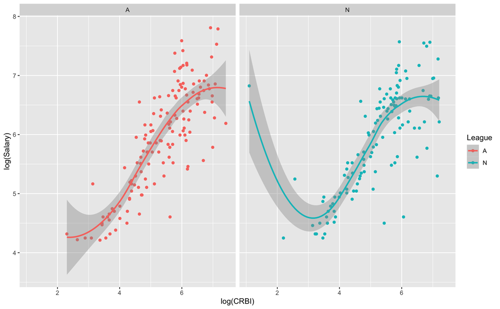

```r
# log Salary and CRBI
ggplot(Hitters2,aes(x=log(CRBI),y=log(Salary),color=League))+geom_point()+geom_smooth(method='loess',formula='y~x')+facet_wrap(~League)
```

## Compare log Salary vs log Salary & CRBI

1. When logging Salary and CRBI it provides a better fit. Able to understand the relationship better with logging.
2. The curvilinear line indicates some polynomial terms may be necessary for a better fit.

## D. The feature selection tool is somewhat automated. You feed it the response and predictors, and it does the rest. Using your previous answers, write a short explanation to a new analyst on why feature selection tools are not a fix-all to the entire modeling process.

1. As an analyst it’s important to understand the purpose of the model. Need to have a good grasp of the data that’s being used and a solid foundation in using best practices in the model building process. For instance EDA, understanding if there are multicollinearity issues, checking model assumptions, terms that should be included in the model. Performing these steps before using feature selection will give you some level of expectation that you want to see. Then can determine if feature selection is on the right path or need to consider other methods.

## E. Examine the following plot that plots penalized regression coefficients versus their penalty term. Provide a high level explanation as to why all of the coefficients are 0 when the log lambda value is 8.

1. In this case the high penalty term at 8 has reduced or removed all of the predictors from the model. The higher the penalty term the fewer predictors.

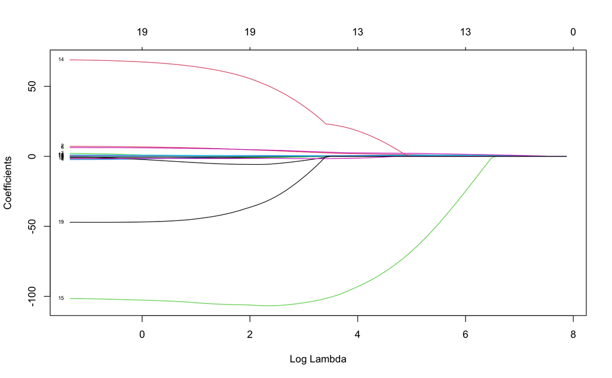

```r
#plots penalized regression coefficients versus their penalty term
library(rgl)
knitr::knit_hooks$set(webgl=hook_webgl)
plot(glmnet.fit$finalModel, xvar = "lambda", label = TRUE)
```

## F. Use the `caret` package to run a 10-fold cross validation to determine an appropriate $k$ when fitting all the numeric predictors (no transformation) to regress Salary (no transformation). Investigate the possible values $k=1,2,3,4,5,6,7,8,9,10,20,30$ using the following option inside of the `train` function.

```r
#10 fold cross validation
tuneGrid=expand.grid(k=c(1:10,20,30)) #Do not run in line.  Must be added inside of train function call. Google is your friend if stuck.
```

```r
#knn 10-fold cross validation

library(caret)

set.seed(1234)
fitControl<-trainControl(method ="repeatedcv",number=10,repeats=1)
knn.fit<-train(Salary ~ AtBat + Hits + HmRun + Runs + RBI + Walks + Years + CAtBat + CHits + CHmRun + CRuns + CRBI + CWalks + PutOuts + Assists + Errors,
               data=Hitters2,
               method="knn",
               tuneGrid=expand.grid(k=c(1:10,20,30)),
               trControl=fitControl
               )

knn.fit
```

```
## k-Nearest Neighbors
##
## 262 samples
##  16 predictor
##
## No pre-processing
## Resampling: Cross-Validated (10 fold, repeated 1 times)
## Summary of sample sizes: 234, 236, 236, 235, 236, 236, ...
## Resampling results across tuning parameters:
##
##   k   RMSE      Rsquared   MAE
##    1  329.0112  0.4989778  211.9339
##    2  332.6004  0.4532158  210.9929
##    3  306.2886  0.5264077  192.6758
##    4  309.3212  0.5159344  192.0025
##    5  308.7630  0.5153132  190.1370
##    6  310.5528  0.5070713  194.0900
##    7  313.3087  0.5030637  193.9748
##    8  314.2945  0.4988067  193.6163
##    9  309.1033  0.5185246  189.7192
##   10  310.9125  0.5108192  191.7531
##   20  314.7961  0.4952994  194.6912
##   30  317.4481  0.4820791  196.8182
##
## RMSE was used to select the optimal model using the smallest value.
## The final value used for the model was k = 3.
```